# Practical Machine Learning/ Prediction Assignment

Yohannes Zerfu

August 19, 2014

### Background

Six young health participants were asked to perform one set of 10 repetitions of the Unilateral Dumbbell Biceps Curl in five different fashions: exactly according to the specification (Class A), throwing the elbows to the front (Class B), lifting the dumbbell only halfway (Class C), lowering the dumbbell only halfway (Class D) and throwing the hips to the front (Class E).

Class A corresponds to the specified execution of the exercise, while the other 4 classes correspond to common mistakes. Participants were supervised by an experienced weight lifter to make sure the execution complied to the manner they were supposed to simulate. The exercises were performed by six male participants aged between 20-28 years, with little weight lifting experience. We made sure that all participants could easily simulate the mistakes in a safe and controlled manner by using a relatively light dumbbell (1.25kg).

### Download and load the data.

The Data is obtained this source: http://groupware.les.inf.puc-rio.br/har

```r
url1="https://d396qusza40orc.cloudfront.net/predmachlearn/pml-training.csv"
url2="https://d396qusza40orc.cloudfront.net/predmachlearn/pml-testing.csv"
download.file(url1, destfile = "pml-training.csv", method = "curl")
download.file(url2, destfile = "pml-testing.csv", method = "curl")

training.data = read.csv("pml-training.csv", na.strings=c("", "NA", "NULL"))

testing.data = read.csv("pml-testing.csv", na.strings=c("", "NA", "NULL"))
dim(training.data)
```

```
## [1] 19622   160
```

```r
dim(testing.data)
```

```
## [1]  20 160
```

#### Pre-screening the data

There are 160 variables in the data sets, we will try to reduce the number of predictors.

1. Remove variables that we believe have too many NA values.

```r
training.noNA <- training.data[ , colSums(is.na(training.data)) == 0]
dim(training.noNA)
```

```
## [1] 19622    60
```

2. Removiing variables that are not related to our dependant variable

```r
remove = c('X', 'user_name', 'raw_timestamp_part_1', 'raw_timestamp_part_2', 'cvtd_timestamp', 'new_window', 'num_window')
training.NIV <- training.noNA[, -which(names(training.noNA) %in% remove)]
dim(training.NIV)
```

```
## [1] 19622    53
```

3. Remove highly correlated variables 90% (using for example findCorrelation()).Note that only numeric Variables can be use here.

```r
corrmatrix <- cor(na.omit(training.NIV[sapply(training.NIV, is.numeric)]))
dim(corrmatrix)
```

```
## [1] 52 52
```

```r
# there are 52 variables.

library('caret')
```

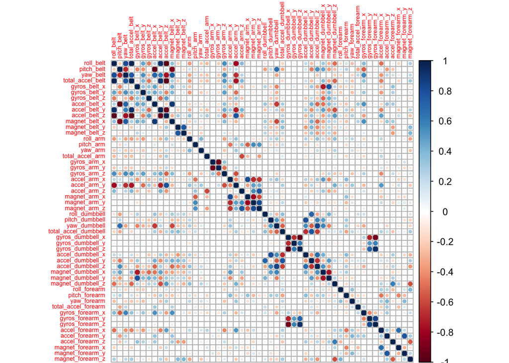

```r
library('corrplot')
corrplot(corrmatrix, method = "circle", tl.cex=.5)
```

```r
# we will then remove variables with high correlation

removecorr = findCorrelation(corrmatrix, cutoff = .90, verbose = FALSE)
training.NHCorr = training.NIV[,-removecorr]
dim(training.NHCorr)
```

```
## [1] 19622    46
```

This resulting data set with 46 variable will be the data that we are going to use for our analysis. The next step is to split (80 - 20 ) our data to training and testing for cross validation.

```r
inTrain <- createDataPartition(y=training.NHCorr$classe, p=0.8, list=FALSE)
training <- training.NHCorr[inTrain,]
testing <- training.NHCorr[-inTrain,]
dim(training);dim(testing)
```

```
## [1] 15699    46
```

```
## [1] 3923   46
```

### Analysis

#### Regression Tree

We will start by fitting a regression tree using “tree” package.

```r
library(tree)
set.seed(3000)
training.tree=tree(classe~., data=training)
summary(training.tree)
```

```
##
## Classification tree:
## tree(formula = classe ~ ., data = training)
## Variables actually used in tree construction:
##  [1] "pitch_forearm"     "magnet_belt_y"     "accel_forearm_z"
##  [4] "magnet_dumbbell_y" "roll_forearm"      "magnet_dumbbell_z"
##  [7] "accel_dumbbell_y"  "pitch_belt"        "yaw_belt"
## [10] "accel_forearm_x"   "accel_dumbbell_z"  "magnet_forearm_y"
## [13] "gyros_belt_z"
## Number of terminal nodes:  20
## Residual mean deviance:  1.68 = 26400 / 15700
## Misclassification error rate: 0.329 = 5167 / 15699
```

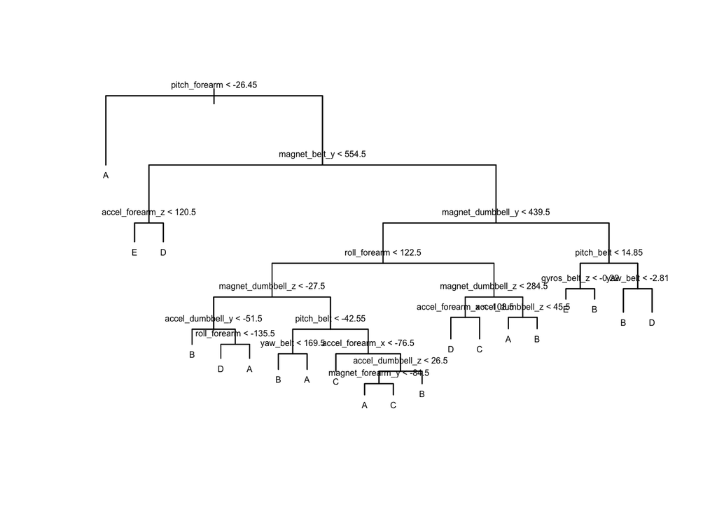

```r
plot(training.tree)
text(training.tree, pretty=0, cex =.5)
```

The next plot is Rpart form Caret a bit slow but good plots

```r
library(caret)
modFit <- train(classe ~ .,method="rpart",data=training)
print(modFit$finalModel)
```

```
## n= 15699
##
## node), split, n, loss, yval, (yprob)
##       * denotes terminal node
##
##  1) root 15699 11240 A (0.28 0.19 0.17 0.16 0.18)
##    2) pitch_forearm< -26.45 1414    63 A (0.96 0.045 0 0 0) *
##    3) pitch_forearm>=-26.45 14285 11170 A (0.22 0.21 0.19 0.18 0.2)
##      6) magnet_belt_y>=555.5 13104  9993 A (0.24 0.23 0.21 0.18 0.15)
##       12) magnet_dumbbell_y< 439.5 10956  7906 A (0.28 0.18 0.24 0.17 0.13)
##         24) roll_forearm< 121.5 6884  4136 A (0.4 0.18 0.19 0.14 0.092) *
##         25) roll_forearm>=121.5 4072  2700 C (0.074 0.18 0.34 0.23 0.18)
##           50) accel_forearm_x>=-108.5 2866  1760 C (0.081 0.22 0.39 0.093 0.22) *
##           51) accel_forearm_x< -108.5 1206   553 D (0.057 0.085 0.22 0.54 0.096) *
##       13) magnet_dumbbell_y>=439.5 2148  1127 B (0.028 0.48 0.036 0.2 0.26) *
##      7) magnet_belt_y< 555.5 1181   229 E (0.0017 0.0034 0.0017 0.19 0.81) *
```

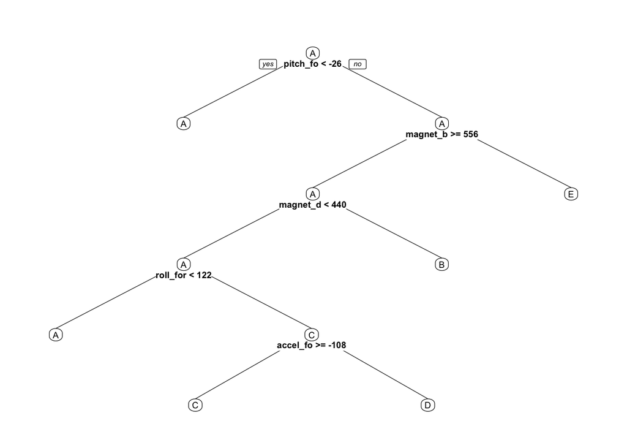

```r
library(rpart.plot)
rpart.plot(modFit$finalModel, cex=0.6, type=2) # basic tree plot
```

### Cross Validation

We are going to check the performance of the tree on the testing data by cross validation.

```r
set.seed(3000)
predict.tree=predict(training.tree,testing,type="class")
predmatrix = with(testing,table(predict.tree,classe))
sum(diag(predmatrix))/sum(as.vector(predmatrix))
```

```
## [1] 0.662
```

```r
set.seed(3000)
predict.tree=predict(modFit,testing)
predmatrix = with(testing,table(predict.tree,classe))
sum(diag(predmatrix))/sum(as.vector(predmatrix))
```

```
## [1] 0.4876
```

This tree was grown to full depth, and might be too variable. We now use Cross Validation to prune it.

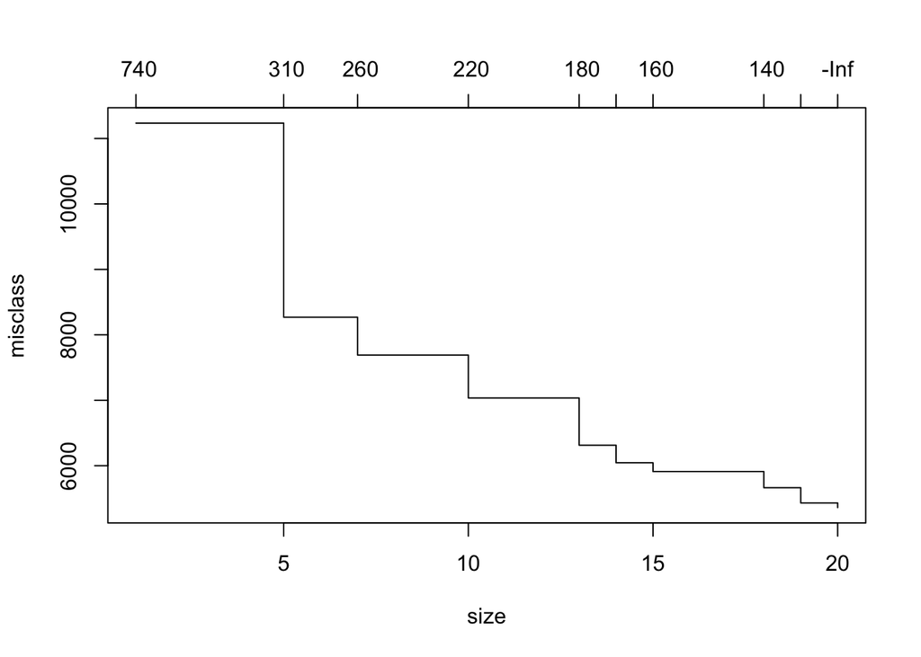

```r
set.seed(3000)
cv.training=cv.tree(training.tree,FUN=prune.misclass)
#cv.training
plot(cv.training)
```

Suppose we prune it at size of nodes at 15.

```r
set.seed(3000)
prune.training=prune.misclass(training.tree,best=15)

#Now lets evaluate this pruned tree on the test data.

tree.pred=predict(prune.training,testing,type="class")
predMatrix = with(testing,table(tree.pred,classe))
sum(diag(predMatrix))/sum(as.vector(predMatrix)) # error rate
```

```
## [1] 0.6204
```

#### Random Forests

This is method for classification that operate by constructing a multitude of decision trees at training time and outputting the class that is the mode of the classes output by individual trees. We will use “randomForcast” r package

```r
library(randomForest)
set.seed(3000)
#Lets fit a random forest and see how well it performs.

rf.training=randomForest(classe~.,data=training,ntree=100, importance=TRUE)
rf.training
```

```
##
## Call:
##  randomForest(formula = classe ~ ., data = training, ntree = 100,      importance = TRUE)
##                Type of random forest: classification
##                      Number of trees: 100
## No. of variables tried at each split: 6
##
##         OOB estimate of  error rate: 0.59%
## Confusion matrix:
##      A    B    C    D    E class.error
## A 4459    3    1    0    1    0.001120
## B   14 3013   10    0    1    0.008229
## C    0   15 2720    3    0    0.006574
## D    0    0   28 2539    6    0.013214
## E    0    0    4    6 2876    0.003465
```

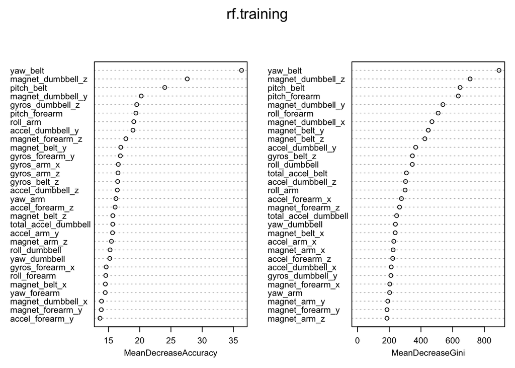

```r
#plot(rf.training, log="y")
varImpPlot(rf.training, cex=0.7)
```

we can see which variables have higher impact on the prediction.

#### Out-of Sample Accuracy

Our Random Forest model shows OOB estimate of error rate: 0.59% for the training data. Now we will predict it for out-of sample accuracy.

Now lets evaluate this tree on the test data.

```r
tree.pred=predict(rf.training,testing,type="class")
predMatrix = with(testing,table(tree.pred,classe))
sum(diag(predMatrix))/sum(as.vector(predMatrix)) # error rate
```

```
## [1] 0.9959
```

0.99 means we got a very accurate estimate.

#### Conclusion

Now let us use our pridiction model to predict 20 diffrent test cases. From the result we can see that the model did produce 20 test cases

```r
testCases <- predict(rf.training, testing.data)
testCases
```

```
##  1  2  3  4  5  6  7  8  9 10 11 12 13 14 15 16 17 18 19 20
##  B  A  B  A  A  E  D  B  A  A  B  C  B  A  E  E  A  B  B  B
## Levels: A B C D E
```